# DST2-Superstore dataset

```python
import numpy as np
import pandas as pd
from matplotlib import pyplot as plt
import seaborn as sns

%matplotlib inline
import time
import plotly.graph_objs as go
import plotly.offline as py

import warnings
warnings.filterwarnings('ignore')
```

```python
data=pd.read_excel("Superstore.xlsx")
```

```python
data.head()
```

|  | Row ID | Order ID | Order Date | Ship Date | Ship Mode | Customer ID | Customer Name | Segment | Country | City | ... | Postal Code | Region | Product ID | Category | Sub-Category | Product Name | Sales | Quantity | Discount | Profit |
| --- | --- | --- | --- | --- | --- | --- | --- | --- | --- | --- | --- | --- | --- | --- | --- | --- | --- | --- | --- | --- | --- |
| 0 | 1 | CA-2018-152156 | 2018-11-08 | 2018-11-11 | Second Class | CG-12520 | Claire Gute | Consumer | US | Henderson | ... | 42420.0 | South | FUR-BO-10001798 | Furniture | Bookcases | Bush Somerset Collection Bookcase | 261.9600 | 2 | 0.00 | 41.9136 |
| 1 | 2 | CA-2018-152156 | 2018-11-08 | 2018-11-11 | Second Class | CG-12520 | Claire Gute | Consumer | US | Henderson | ... | 42420.0 | South | FUR-CH-10000454 | Furniture | Chairs | Hon Deluxe Fabric Upholstered Stacking Chairs,... | 731.9400 | 3 | 0.00 | 219.5820 |
| 2 | 3 | CA-2018-138688 | 2018-06-12 | 2018-06-16 | Second Class | DV-13045 | Darrin Van Huff | Corporate | US | Los Angeles | ... | 90036.0 | West | OFF-LA-10000240 | Office Supplies | Labels | Self-Adhesive Address Labels for Typewriters b... | 14.6200 | 2 | 0.00 | 6.8714 |
| 3 | 4 | US-2017-108966 | 2017-10-11 | 2017-10-18 | Standard Class | SO-20335 | Sean O'Donnell | Consumer | US | Fort Lauderdale | ... | 33311.0 | South | FUR-TA-10000577 | Furniture | Tables | Bretford CR4500 Series Slim Rectangular Table | 957.5775 | 5 | 0.45 | -383.0310 |
| 4 | 5 | US-2017-108966 | 2017-10-11 | 2017-10-18 | Standard Class | SO-20335 | Sean O'Donnell | Consumer | US | Fort Lauderdale | ... | 33311.0 | South | OFF-ST-10000760 | Office Supplies | Storage | Eldon Fold 'N Roll Cart System | 22.3680 | 2 | 0.20 | 2.5164 |

5 rows × 21 columns

```python
data.shape
```

```
(9994, 21)
```

# Summary of data:

```python
data.info()
```

```
<class 'pandas.core.frame.DataFrame'>
RangeIndex: 9994 entries, 0 to 9993
Data columns (total 21 columns):
 #   Column         Non-Null Count  Dtype
---  ------         --------------  -----
 0   Row ID         9994 non-null   int64
 1   Order ID       9994 non-null   object
 2   Order Date     9994 non-null   datetime64[ns]
 3   Ship Date      9994 non-null   datetime64[ns]
 4   Ship Mode      9994 non-null   object
 5   Customer ID    9994 non-null   object
 6   Customer Name  9994 non-null   object
 7   Segment        9994 non-null   object
 8   Country        9994 non-null   object
 9   City           9994 non-null   object
 10  State          9994 non-null   object
 11  Postal Code    9983 non-null   float64
 12  Region         9994 non-null   object
 13  Product ID     9994 non-null   object
 14  Category       9994 non-null   object
 15  Sub-Category   9994 non-null   object
 16  Product Name   9994 non-null   object
 17  Sales          9994 non-null   float64
 18  Quantity       9994 non-null   int64
 19  Discount       9994 non-null   float64
 20  Profit         9994 non-null   float64
dtypes: datetime64[ns](2), float64(4), int64(2), object(13)
memory usage: 1.1+ MB
```

# Total Unique Values:

```python
data.nunique()
```

```
Row ID           9994
Order ID         5009
Order Date       1236
Ship Date        1334
Ship Mode           4
Customer ID       793
Customer Name     793
Segment             3
Country             1
City              531
State              49
Postal Code       630
Region              4
Product ID       1862
Category            3
Sub-Category       17
Product Name     1850
Sales            6144
Quantity           14
Discount           12
Profit           7545
dtype: int64
```

# Total Missing Values:

```python
data.isnull().sum()
```

```
Row ID            0
Order ID          0
Order Date        0
Ship Date         0
Ship Mode         0
Customer ID       0
Customer Name     0
Segment           0
Country           0
City              0
State             0
Postal Code      11
Region            0
Product ID        0
Category          0
Sub-Category      0
Product Name      0
Sales             0
Quantity          0
Discount          0
Profit            0
dtype: int64
```

```python
data.drop(columns=['Row ID','Order ID','Postal Code'],inplace=True)
```

```python
data['order year']=pd.DatetimeIndex(data['Order Date']).year
```

```python
data['order year'].unique()
```

```
array([2018, 2017, 2016, 2019], dtype=int64)
```

# Summary Statistics:

```python
data.describe()
```

|  | Sales | Quantity | Discount | Profit | order year |
| --- | --- | --- | --- | --- | --- |
| count | 9994.000000 | 9994.000000 | 9994.000000 | 9994.000000 | 9994.000000 |
| mean | 229.858001 | 3.789574 | 0.156203 | 28.656896 | 2017.722233 |
| std | 623.245101 | 2.225110 | 0.206452 | 234.260108 | 1.123555 |
| min | 0.444000 | 1.000000 | 0.000000 | -6599.978000 | 2016.000000 |
| 25% | 17.280000 | 2.000000 | 0.000000 | 1.728750 | 2017.000000 |
| 50% | 54.490000 | 3.000000 | 0.200000 | 8.666500 | 2018.000000 |
| 75% | 209.940000 | 5.000000 | 0.200000 | 29.364000 | 2019.000000 |
| max | 22638.480000 | 14.000000 | 0.800000 | 8399.976000 | 2019.000000 |

# Exploratory Data Analysis:

# Univariate Analysis:

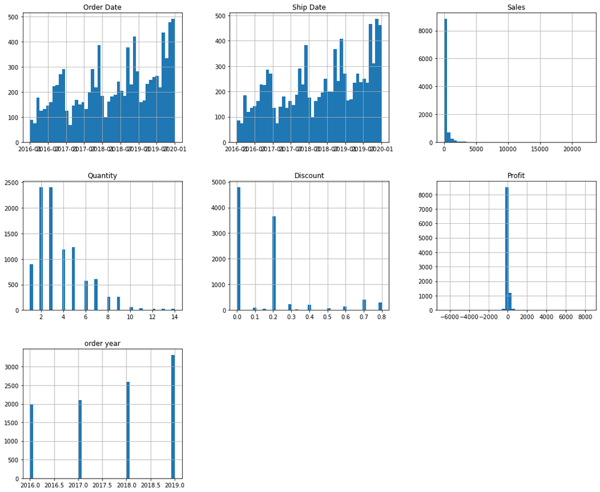

```python
data.hist(bins=45, figsize=(18,15))
plt.show()
```

# Boxplot:

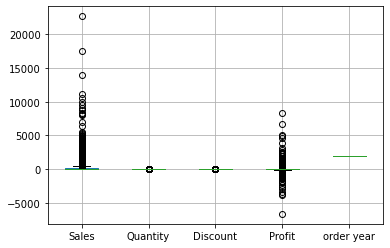

```python
data.boxplot()
```

# Distribution Plot:

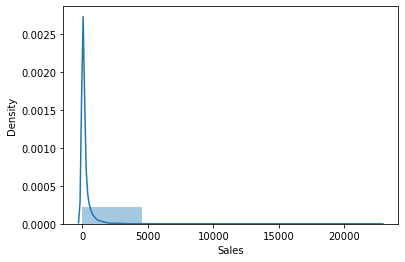

```python
sns.distplot(data['Sales'], bins=5)
```

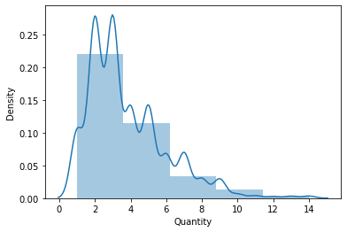

```python
sns.distplot(data['Quantity'], bins=5)
```

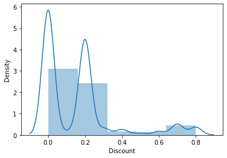

```python
sns.distplot(data['Discount'], bins=5)
```

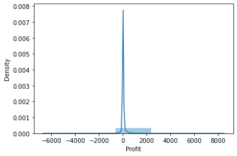

```python
sns.distplot(data['Profit'], bins=5)
```

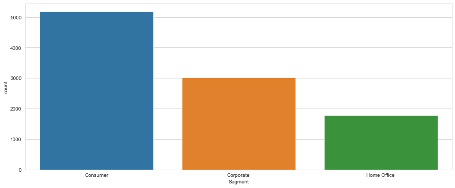

```python
sns.set_style("whitegrid")
plt.figure(figsize = (15,6))
sns.countplot(x = 'Segment', data = data)
```

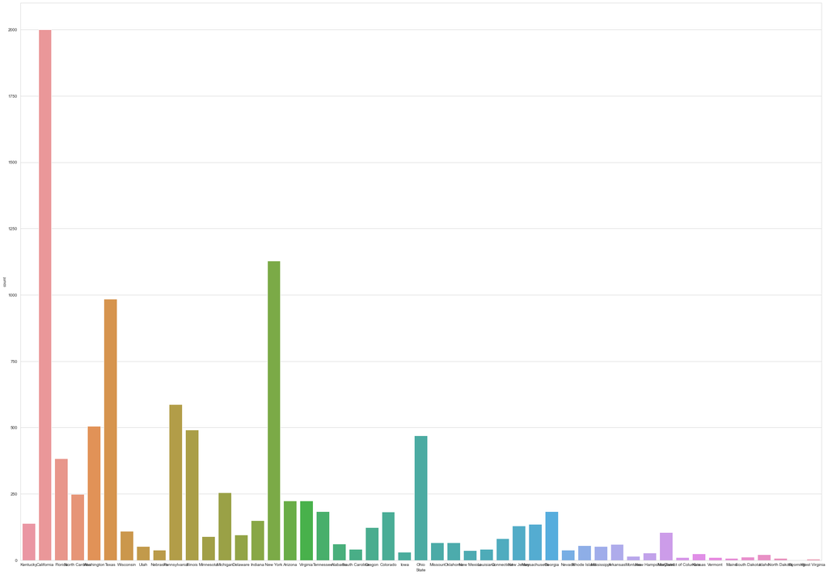

```python
sns.set_style("whitegrid")
plt.figure(figsize = (35,25))
sns.countplot(x = 'State', data = data)
```

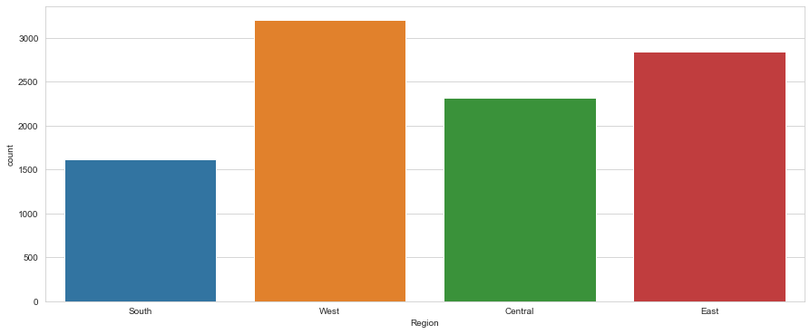

```python
sns.set_style("whitegrid")
plt.figure(figsize = (15,6))
sns.countplot(x = 'Region', data = data)
```

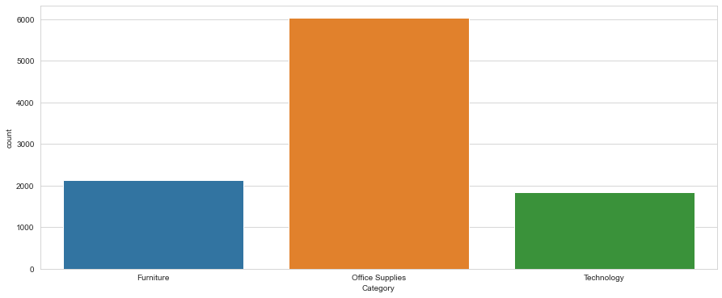

```python
sns.set_style("whitegrid")
plt.figure(figsize = (15,6))
sns.countplot(x = 'Category', data = data)
```

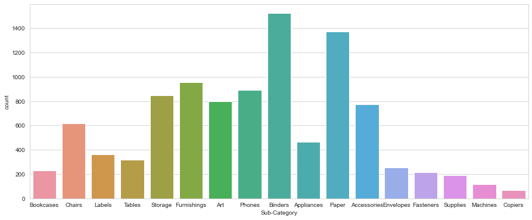

```python
sns.set_style("whitegrid")
plt.figure(figsize = (15,6))
sns.countplot(x = 'Sub-Category', data = data)
```

# Bivariate Analysis:

# Category Wise Comparision:

```
Category
Furniture          349.834887
Office Supplies    119.324101
Technology         452.709276
Name: Sales, dtype: float64
```

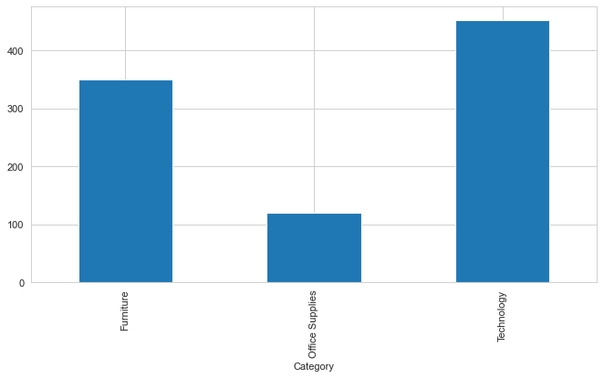

```python
plt.figure(figsize=[10,5],dpi=80)
data.groupby('Category',)['Sales'].mean().plot(kind='bar')
data.groupby('Category')['Sales'].mean()
```

- Category technology get more sale as compare to other categories.

```
Category
Furniture          3.785007
Office Supplies    3.801195
Technology         3.756903
Name: Quantity, dtype: float64
```

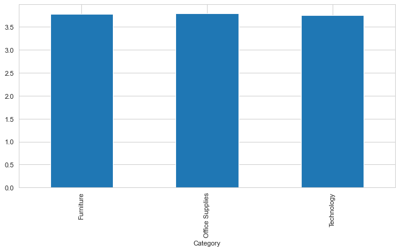

```python
plt.figure(figsize=[10,5],dpi=80)
data.groupby('Category',)['Quantity'].mean().plot(kind='bar')
data.groupby('Category')['Quantity'].mean()
```

- All categories quantity is almost same.

```
Category
Furniture          0.173923
Office Supplies    0.157285
Technology         0.132323
Name: Discount, dtype: float64
```

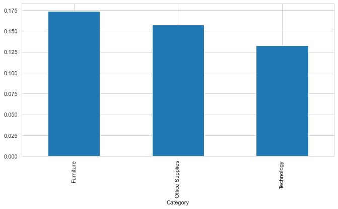

```python
plt.figure(figsize=[10,5],dpi=80)
data.groupby('Category',)['Discount'].mean().plot(kind='bar')
data.groupby('Category')['Discount'].mean()
```

- Little bit more discounts are given on category furniture as compare to it other categories.

```
Category
Furniture           8.699327
Office Supplies    20.327050
Technology         78.752002
Name: Profit, dtype: float64
```

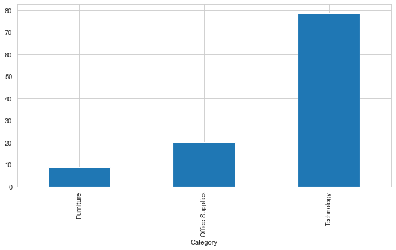

```python
plt.figure(figsize=[10,5],dpi=80)
data.groupby('Category',)['Profit'].mean().plot(kind='bar')
data.groupby('Category')['Profit'].mean()
```

- The most profitable category is technology.

# Sub-Category Wise Comparision:

```
Sub-Category
Accessories     215.974604
Appliances      230.755710
Art              34.068834
Binders         133.560560
Bookcases       503.859633
Chairs          532.332420
Copiers        2198.941618
Envelopes        64.867724
Fasteners        13.936774
Furnishings      95.825668
Labels           34.303055
Machines       1645.553313
Paper            57.284092
Phones          371.211534
Storage         264.590553
Supplies        245.650200
Tables          648.794771
Name: Sales, dtype: float64
```

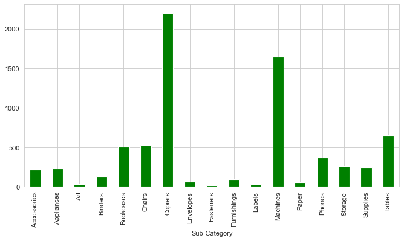

```python
plt.figure(figsize=[10,5],dpi=80)
data.groupby('Sub-Category',)['Sales'].mean().plot(kind='bar',color='green')
data.groupby('Sub-Category')['Sales'].mean()
```

- Sub-Category Copiers and machines are sold well as compare to other.
- Sales of sub-category art, binders, envelopes, fasteners, labels and paper are less .

```
Sub-Category
Accessories    3.840000
Appliances     3.710300
Art            3.768844
Binders        3.922521
Bookcases      3.807018
Chairs         3.818476
Copiers        3.441176
Envelopes      3.566929
Fasteners      4.211982
Furnishings    3.723093
Labels         3.846154
Machines       3.826087
Paper          3.779562
Phones         3.699663
Storage        3.732861
Supplies       3.405263
Tables         3.890282
Name: Quantity, dtype: float64
```

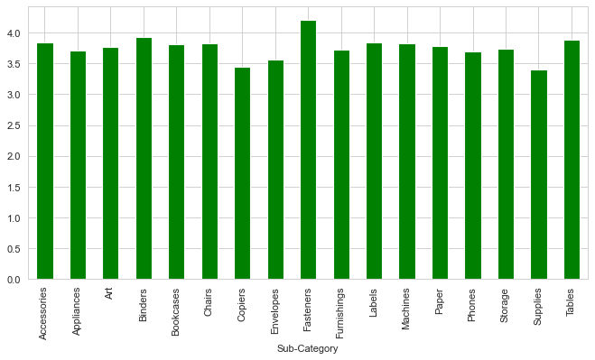

```python
plt.figure(figsize=[10,5],dpi=80)
data.groupby('Sub-Category',)['Quantity'].mean().plot(kind='bar',color='green')
data.groupby('Sub-Category')['Quantity'].mean()
```

- All sub-categories quantity is almost same.

```
Sub-Category
Accessories    0.078452
Appliances     0.166524
Art            0.074874
Binders        0.372292
Bookcases      0.211140
Chairs         0.170178
Copiers        0.161765
Envelopes      0.080315
Fasteners      0.082028
Furnishings    0.138349
Labels         0.068681
Machines       0.306087
Paper          0.074891
Phones         0.154556
Storage        0.074704
Supplies       0.076842
Tables         0.261285
Name: Discount, dtype: float64
```

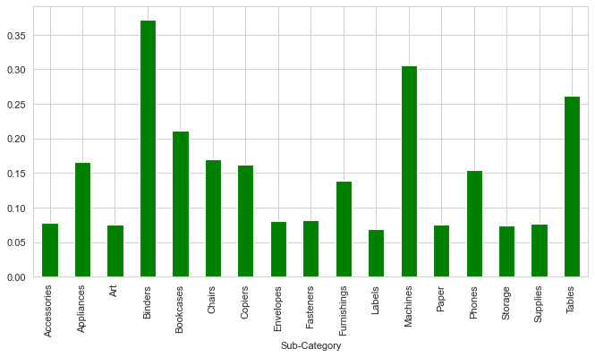

```python
plt.figure(figsize=[10,5],dpi=80)
data.groupby('Sub-Category',)['Discount'].mean().plot(kind='bar',color='green')
data.groupby('Sub-Category')['Discount'].mean()
```

- High discounts have been given on binders, machines and tables as compare to others.

```
Sub-Category
Accessories     54.111788
Appliances      38.922758
Art              8.200737
Binders         19.843574
Bookcases      -15.230509
Chairs          43.095894
Copiers        817.909190
Envelopes       27.418019
Fasteners        4.375660
Furnishings     13.645918
Labels          15.236962
Machines        29.432669
Paper           24.856620
Phones          50.073938
Storage         25.152277
Supplies        -6.258418
Tables         -55.565771
Name: Profit, dtype: float64
```

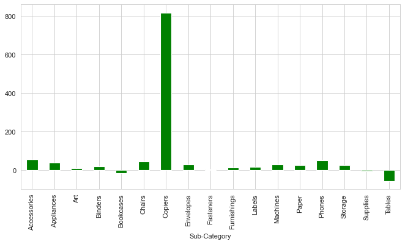

```python
plt.figure(figsize=[10,5],dpi=80)
data.groupby('Sub-Category',)['Profit'].mean().plot(kind='bar',color='green')
data.groupby('Sub-Category')['Profit'].mean()
```

- Sub-category copiers getting more profit as compare to others.
- bookcases, supplies and tables are in loss

# Region Wise Comparision:

```
Region
Central    215.772661
East       238.336110
South      241.803645
West       226.493233
Name: Sales, dtype: float64
```

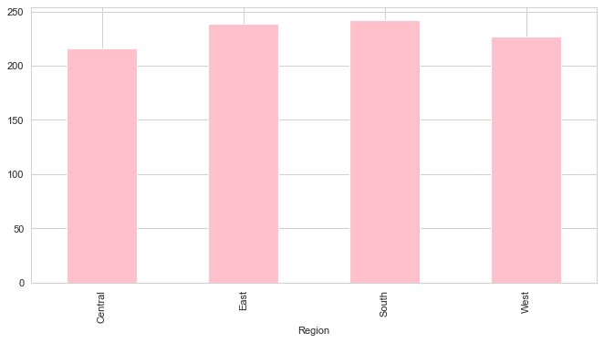

```python
plt.figure(figsize=[10,5],dpi=80)
data.groupby('Region',)['Sales'].mean().plot(kind='bar',color='pink')
data.groupby('Region')['Sales'].mean()
```

- Sales of central region is low as compare to other region.

```
Region
Central    3.779595
East       3.728230
South      3.832716
West       3.829535
Name: Quantity, dtype: float64
```

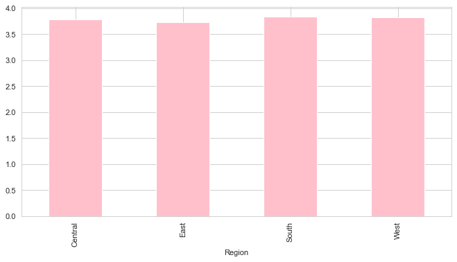

```python
plt.figure(figsize=[10,5],dpi=80)
data.groupby('Region',)['Quantity'].mean().plot(kind='bar',color='pink')
data.groupby('Region')['Quantity'].mean()
```

- Quantity of all region is almost same.

```
Region
Central    0.240353
East       0.145365
South      0.147253
West       0.109335
Name: Discount, dtype: float64
```

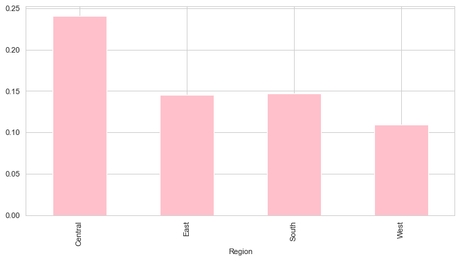

```python
plt.figure(figsize=[10,5],dpi=80)
data.groupby('Region')['Discount'].mean().plot(kind='bar',color='pink')
data.groupby('Region')['Discount'].mean()
```

- More discount are being offered in cental region.

```
Region
Central    17.092709
East       32.135808
South      28.857673
West       33.849032
Name: Profit, dtype: float64
```

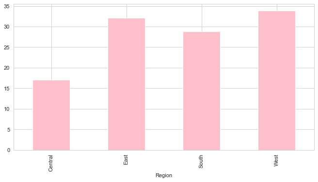

```python
plt.figure(figsize=[10,5],dpi=80)
data.groupby('Region',)['Profit'].mean().plot(kind='bar',color='pink')
data.groupby('Region')['Profit'].mean()
```

- The lowest profit is in the central region.

# Segment Wise Comparision:

```
Segment
Consumer       223.733644
Corporate      233.823300
Home Office    240.972041
Name: Sales, dtype: float64
```

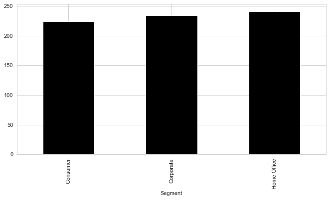

```python
plt.figure(figsize=[10,5],dpi=80)
data.groupby('Segment',)['Sales'].mean().plot(kind='bar',color='black')
data.groupby('Segment')['Sales'].mean()
```

- All segments sale is almost same.

```
Segment
Consumer       3.760547
Corporate      3.843709
Home Office    3.782389
Name: Quantity, dtype: float64
```

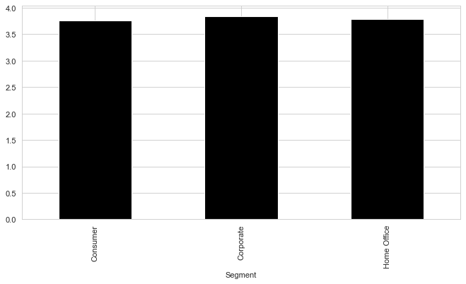

```python
plt.figure(figsize=[10,5],dpi=80)
data.groupby('Segment',)['Quantity'].mean().plot(kind='bar',color='black')
data.groupby('Segment')['Quantity'].mean()
```

## Quantity is also same for all segment.

```
Segment
Consumer       0.158141
Corporate      0.158228
Home Office    0.147128
Name: Discount, dtype: float64
```

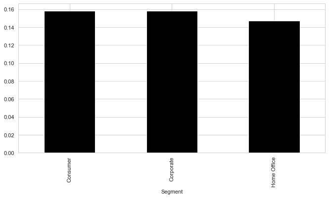

```python
plt.figure(figsize=[10,5],dpi=80)
data.groupby('Segment',)['Discount'].mean().plot(kind='bar',color='black')
data.groupby('Segment')['Discount'].mean()
```

- The discount is almost same in all segments.

```
Segment
Consumer       25.836873
Corporate      30.456667
Home Office    33.818664
Name: Profit, dtype: float64
```

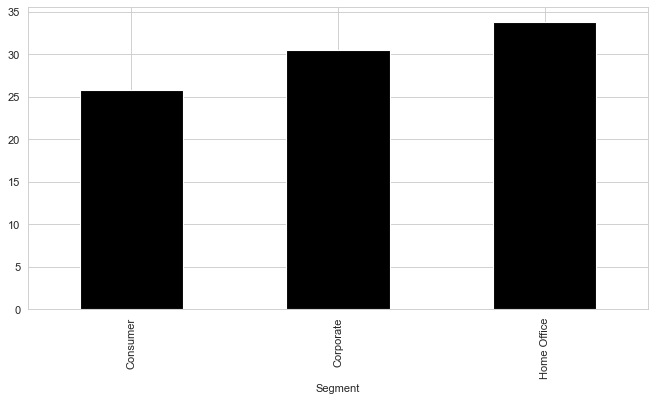

```python
plt.figure(figsize=[10,5],dpi=80)
data.groupby('Segment',)['Profit'].mean().plot(kind='bar',color='black')
data.groupby('Segment')['Profit'].mean()
```

- The highest profit comes from segment home office.

# Multivariate Analysis:

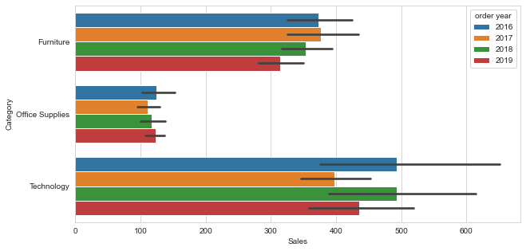

```python
plt.figure(figsize=(10,5))
sns.barplot(x='Sales',y='Category',hue='order year',data=data)
```

- The highest sales were in category technology and it have been in year 2016 and 2018.

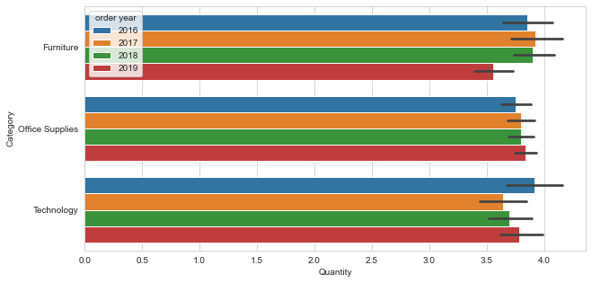

```python
plt.figure(figsize=(10,5))
sns.barplot(x='Quantity',y='Category',hue='order year',data=data)
```

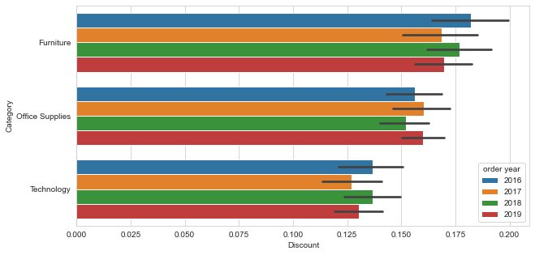

```python
plt.figure(figsize=(10,5))
sns.barplot(x='Discount',y='Category',hue='order year',data=data)
```

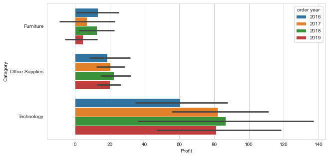

```python
plt.figure(figsize=(10,5))
sns.barplot(x='Profit',y='Category',hue='order year',data=data)
```

# For Subcategory:

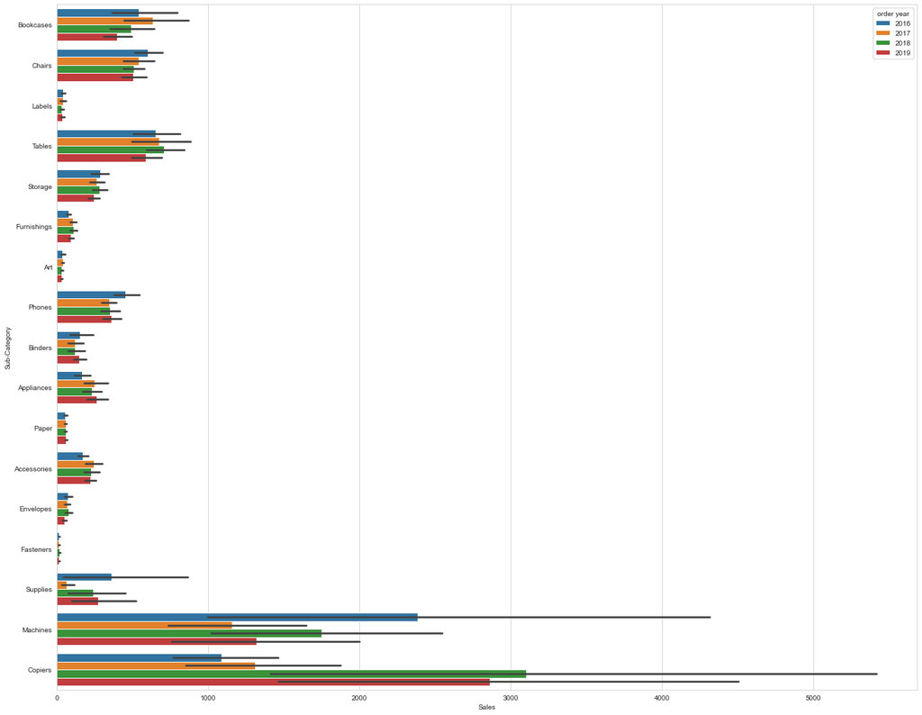

```python
plt.figure(figsize=(22,18))
sns.barplot(x='Sales',y='Sub-Category',hue='order year',data=data)
```

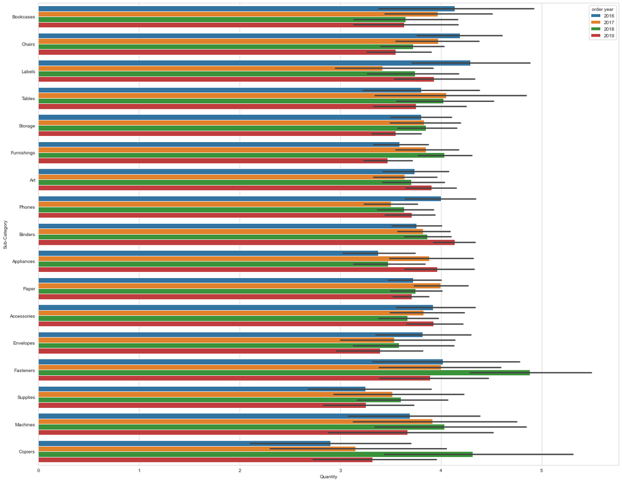

```python
plt.figure(figsize=(22,18))
sns.barplot(x='Quantity',y='Sub-Category',hue='order year',data=data)
```

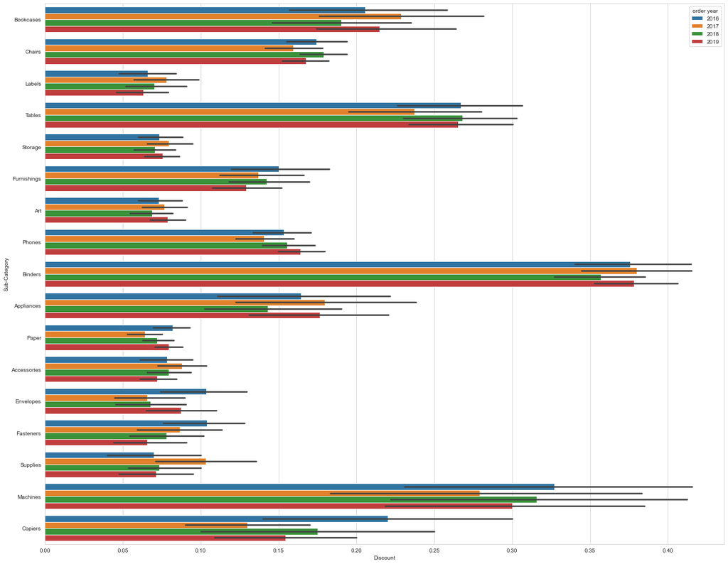

```python
plt.figure(figsize=(22,18))
sns.barplot(x='Discount',y='Sub-Category',hue='order year',data=data)
```

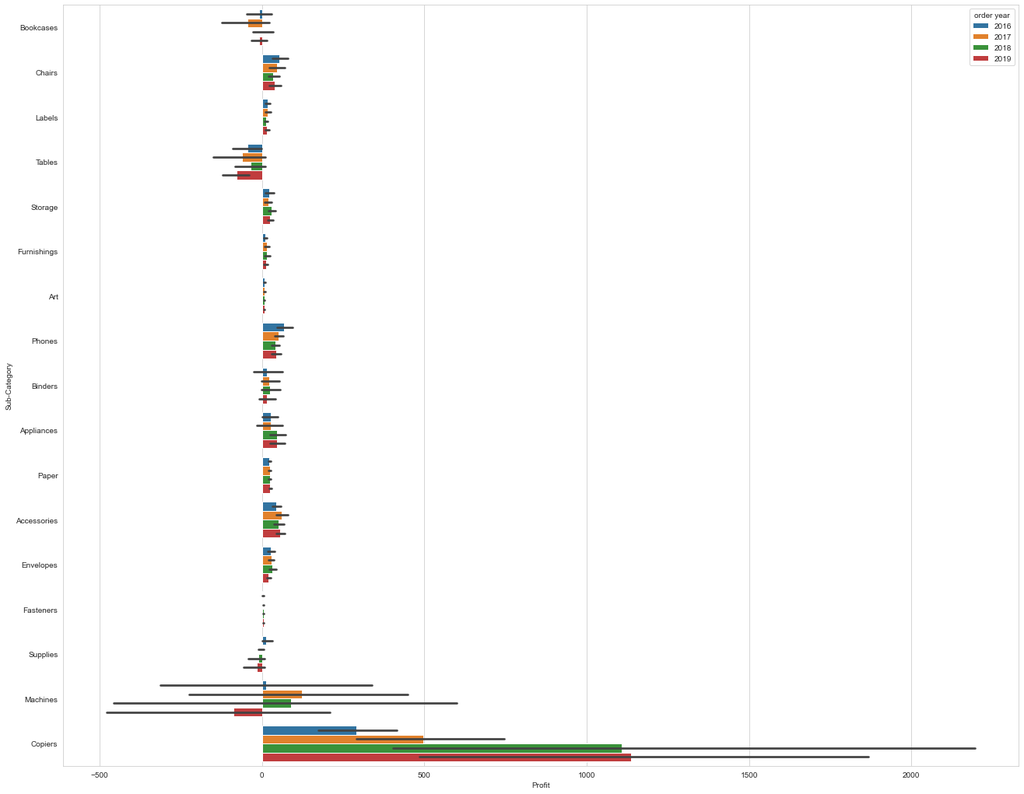

```python
plt.figure(figsize=(22,18))
sns.barplot(x='Profit',y='Sub-Category',hue='order year',data=data)
```